# DataWhale 组队学习 R语言数据分析 Task02 数据清洗与准备

### 4.2 标签编码

标签编码(Label Encoder)是将类别变量转换成连续的数值型变量，通常对有序的变量进行标签编码，既保留了顺序信息，也节约了空间（不会扩充变量）

R里有一个特殊的结构factor（factor是有序的分类变量），我们这里可以利用factor来做标签编码。首先根据实际情况设置factor的类别顺序，然后直接用`as.numeric()`转化为数字。

```r
h1n1_data_complete_lab_encoder <- h1n1_data_complete
h1n1_data_complete_lab_encoder$income_poverty_lab_encoder <- as.numeric(factor(h1n1_data_complete_lab_encoder$income_poverty,
    levels = c("Below Poverty", "<= $75,000, Above Poverty", "> $75,000")))
head(subset(h1n1_data_complete_lab_encoder, select = c(income_poverty, income_poverty_lab_encoder)))
```

```
##              income_poverty income_poverty_lab_encoder
## 1             Below Poverty                          1
## 2             Below Poverty                          1
## 3 <= $75,000, Above Poverty                          2
## 4             Below Poverty                          1
## 5 <= $75,000, Above Poverty                          2
## 6 <= $75,000, Above Poverty                          2
```

### 4.3 手动编码

比如，当某一个特征中有很多类别，我们认为某些类别可以合为一类，可以用`case_when()`函数手动处理。

```r
h1n1_data_manual <- subset(h1n1_data_complete, select = c(age_group))
h1n1_data_manual$age_group_manual <- case_when(h1n1_data_manual$age_group %in% c("18 - 34 Years") ~
    1, h1n1_data_manual$age_group %in% c("35 - 44 Years", "45 - 54 Years", "55 - 64 Years") ~
    2, h1n1_data_manual$age_group %in% c("65+ Years") ~ 3)
head(h1n1_data_manual)
```

```
##       age_group age_group_manual
## 1 55 - 64 Years                2
## 2 35 - 44 Years                2
## 3 18 - 34 Years                1
## 4     65+ Years                3
## 5 45 - 54 Years                2
## 6     65+ Years                3
```

### 4.4 日期特征转换

参考附录`R语言日期时间处理`

## 5 规范化与偏态数据

为什么要数据规范化？简单来说是为了去除数据量纲和数据大小的差异，确保数据是在同一量纲或者同一数量级下进行比较，一般用在机器学习算法之前。数据规范化又可以使用0-1规范化，Z-score等方法。 为什么要处理偏态数据？。很多模型会假设数据或参数服从正态分布。例如线性回归(linear regression)，它假设误差服从正态分布。

提示：注意在测试数据与训练数据分布差别很大的情况下，对测试数据运用一些规范化方法时，可能因为数据分布不匹配而带来误差。

这里我们使用波士顿房价数据集来做演示。可以看到图中数据的偏态分布及量纲差别。

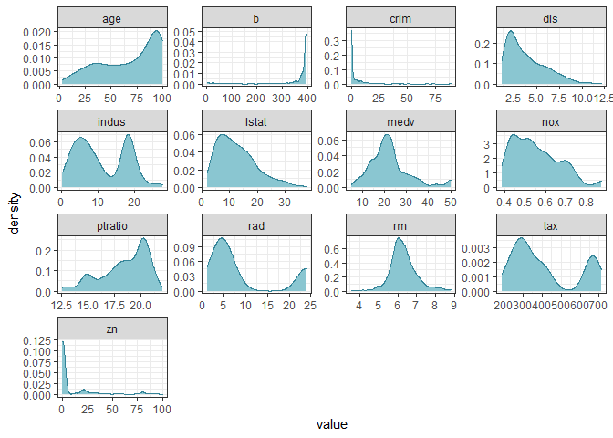

```r
BostonHousing %>%
    keep(is.numeric) %>%
    gather() %>%
    ggplot(aes(value)) + facet_wrap(~key, scales = "free") + geom_density(color = "#348498",
    fill = "#8ac6d1") + theme_bw()
```

### 5.1 0-1规范化

这里用循环计算出每一列的最大最小值，再根据公式求出缩放后的数据。

```r
nums_data_norm1 <- nums_data
for (col in names(nums_data_norm1)) {
    xmin <- min(nums_data_norm1[col])
    xmax <- max(nums_data_norm1[col])
    nums_data_norm1[col] <- (nums_data_norm1[col] - xmin)/(xmax - xmin)
}

head(nums_data_norm1)
```

```
##           crim   zn      indus       nox        rm       age       dis
## 1 0.0000000000 0.18 0.06781525 0.3148148 0.5775053 0.6416066 0.2692031
## 2 0.0002359225 0.00 0.24230205 0.1728395 0.5479977 0.7826982 0.3489620
## 3 0.0002356977 0.00 0.24230205 0.1728395 0.6943859 0.5993821 0.3489620
## 4 0.0002927957 0.00 0.06304985 0.1502058 0.6585553 0.4418126 0.4485446
## 5 0.0007050701 0.00 0.06304985 0.1502058 0.6871048 0.5283213 0.4485446
## 6 0.0002644715 0.00 0.06304985 0.1502058 0.5497222 0.5746653 0.4485446
##          rad        tax   ptratio         b      lstat      medv
## 1 0.00000000 0.20801527 0.2872340 1.0000000 0.08967991 0.4222222
## 2 0.04347826 0.10496183 0.5531915 1.0000000 0.20447020 0.3688889
## 3 0.04347826 0.10496183 0.5531915 0.9897373 0.06346578 0.6600000
## 4 0.08695652 0.06679389 0.6489362 0.9942761 0.03338852 0.6311111
## 5 0.08695652 0.06679389 0.6489362 1.0000000 0.09933775 0.6933333
## 6 0.08695652 0.06679389 0.6489362 0.9929901 0.09602649 0.5266667
```

转换完再看一下分布，已经缩放到0-1之间了。

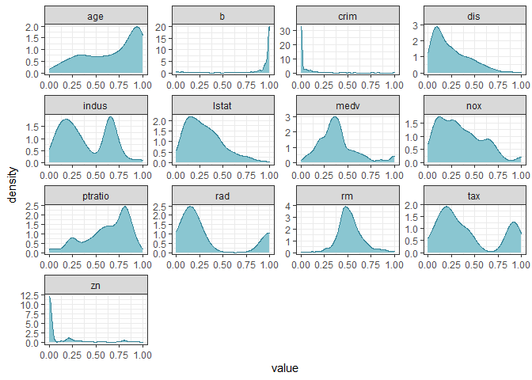

```r
nums_data_norm1 %>%
    keep(is.numeric) %>%
    gather() %>%
    ggplot(aes(value)) + facet_wrap(~key, scales = "free") + geom_density(color = "#348498",
    fill = "#8ac6d1") + theme_bw()
```

此外可以用dlookr包里的`transform()`函数。

```r
nums_data_norm2 <- nums_data
nums_data_norm2$crim <- dlookr::transform(nums_data$crim, method = "minmax")
```

### 5.2 Z-score标准化

Z-score标准化是原数据减去期望再除以标准差，将数据按比例缩放，使其落入到一个小的区间内，标准化后的数据可正可负，但是一般绝对值不会太大。

R里面可以用`scale()`函数来计算z-score。也可以dlookr包里的中`transform()`函数。

```r
nums_data_zscore <- nums_data
nums_data_zscore <- scale(nums_data_zscore)
head(nums_data_zscore)
```

```
##         crim         zn      indus        nox        rm        age      dis
## 1 -0.4193669  0.2845483 -1.2866362 -0.1440749 0.4132629 -0.1198948 0.140075
## 2 -0.4169267 -0.4872402 -0.5927944 -0.7395304 0.1940824  0.3668034 0.556609
## 3 -0.4169290 -0.4872402 -0.5927944 -0.7395304 1.2814456 -0.2655490 0.556609
## 4 -0.4163384 -0.4872402 -1.3055857 -0.8344581 1.0152978 -0.8090878 1.076671
## 5 -0.4120741 -0.4872402 -1.3055857 -0.8344581 1.2273620 -0.5106743 1.076671
## 6 -0.4166314 -0.4872402 -1.3055857 -0.8344581 0.2068916 -0.3508100 1.076671
##          rad        tax    ptratio         b      lstat       medv
## 1 -0.9818712 -0.6659492 -1.4575580 0.4406159 -1.0744990  0.1595278
## 2 -0.8670245 -0.9863534 -0.3027945 0.4406159 -0.4919525 -0.1014239
## 3 -0.8670245 -0.9863534 -0.3027945 0.3960351 -1.2075324  1.3229375
## 4 -0.7521778 -1.1050216  0.1129203 0.4157514 -1.3601708  1.1815886
## 5 -0.7521778 -1.1050216  0.1129203 0.4406159 -1.0254866  1.4860323
## 6 -0.7521778 -1.1050216  0.1129203 0.4101651 -1.0422909  0.6705582
```

转换完再看一下分布，数据缩放后在0周围的一个小区间了。

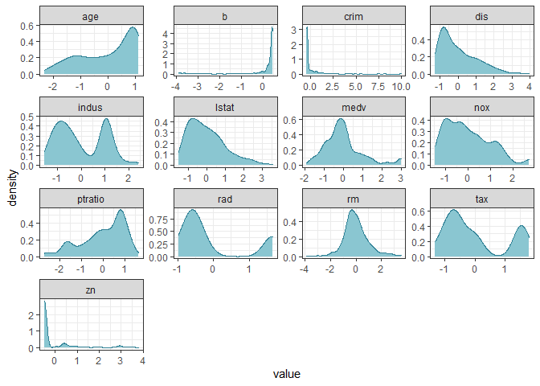

```r
data.frame(nums_data_zscore) %>%
    keep(is.numeric) %>%
    gather() %>%
    ggplot(aes(value)) + facet_wrap(~key, scales = "free") + geom_density(color = "#348498",
    fill = "#8ac6d1") + theme_bw()
```

### 5.3 对数转换(log transform)

```r
# 直接公式转换
nums_data_log1p1 <- log(nums_data + 1)

# 用transform()函数
nums_data_log1p2 <- nums_data
nums_data_log1p2$b <- dlookr::transform(nums_data_log1p2$b, method = "log+1")
```

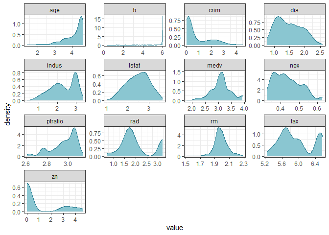

```r
nums_data_log1p1 %>%
    keep(is.numeric) %>%
    gather() %>%
    ggplot(aes(value)) + facet_wrap(~key, scales = "free") + geom_density(color = "#348498",
    fill = "#8ac6d1") + theme_bw()
```

### 5.4 Box-Cox

Box-Cox变换是Box和Cox在1964年提出的一种广义幂变换方法，在变换后可以一定程度上减小不可观测的误差和预测变量的相关性，在机器学习中经常用来处理偏态分布。其一个显著优点是通过求变换参数来确定变换形式，而这个过程完全基于数据本身而无须任何先验信息，这无疑比凭经验或通过尝试而选用对数、平方根等变换方式要客观和精确。计算公式如下：

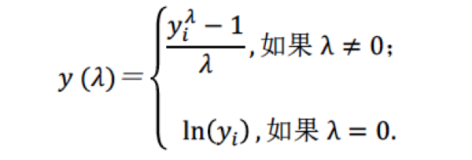

示例参考附录`基于R语言进行Box-Cox变换`

## 6 小拓展

R语言中，mutate 类似于SQL中，根据表的现有变量，生成新变量。使用mutate集中处理变量转换，代码显示较整洁。

```r
 h1n1_data_de <- h1n1_data_complete %>% to_dummy(education, suffix = "label")  %>%
  bind_cols(h1n1_data_complete)  %>%
  mutate(
    #标签编码(label encoder)
    sex = as.factor(as.numeric(factor(sex))),
    income_poverty = (as.numeric(factor(
      income_poverty,
      levels = c(
        "Below Poverty",
        "<= $75,000, Above Poverty",
        "> $75,000"
      )
    ))),
    #手动编码
    age_group = as.factor(
      case_when(
        age_group  %in% c("18 - 34 Years") ~ 1,
        age_group  %in% c("35 - 44 Years","45 - 54 Years","55 - 64 Years") ~ 2,
        age_group  %in% c("65+ Years") ~ 3
      )),
     #标准化
    across(
      c("h1n1_knowledge",
        "doctor_recc_h1n1",
        "chronic_med_condition",
        "opinion_h1n1_vacc_effective",
        "age_group",
        "income_poverty"),
       ~ scale(as.numeric(.x))
    )
  )  %>% dplyr::select(-one_of("education","education_"))

head( h1n1_data_de)
```

```
##   education_< 12 Years education_12 Years education_College Graduate
## 1                    1                  0                          0
## 2                    0                  1                          0
## 3                    0                  0                          1
## 4                    0                  1                          0
## 5                    0                  0                          0
## 6                    0                  1                          0
##   education_Some College respondent_id h1n1_knowledge doctor_recc_h1n1
## 1                      0             0     -2.0416901       -0.5258839
## 2                      0             1      1.1935904       -0.5258839
## 3                      0             2     -0.4240499       -0.5258839
## 4                      0             3     -0.4240499       -0.5258839
## 5                      1             4     -0.4240499       -0.5258839
## 6                      0             5     -0.4240499       -0.5258839
##   chronic_med_condition health_insurance opinion_h1n1_vacc_effective
## 1            -0.6284091                1                  -0.8439071
## 2            -0.6284091                1                   1.1407906
## 3             1.5912605                1                  -0.8439071
## 4             1.5912605                1                  -0.8439071
## 5            -0.6284091                0                  -0.8439071
## 6            -0.6284091                1                   1.1407906
##     age_group sex income_poverty h1n1_vaccine
## 1 -0.09109418   1     -1.8905904            0
## 2 -0.09109418   2     -1.8905904            0
## 3 -1.58547517   2     -0.2945789            0
## 4  1.40328681   1     -1.8905904            0
## 5 -0.09109418   1     -0.2945789            0
## 6  1.40328681   2     -0.2945789            0
```

注意在机器学习中，尽量在数据集划分后，分别在训练集与验证集、测试集上进行数据清洗，避免数据泄露。R中的数据集划分方法参考附录`R中数据集分割`。

## 思考与练习

看完了本节数据清洗与准备，尝试着选取一个完整的数据集（从本节中选取或使用自己的数据集），来做一次清洗吧！

## 附录：参考资料

### 理论资料

**数据的预处理基础：** 如何处理缺失值 https://cloud.tencent.com/developer/article/1626004

**多重插补法：** 处理缺失值之多重插补（Multiple Imputation）https://zhuanlan.zhihu.com/p/36436260

**异常值检测：** R语言–异常值检测 https://blog.csdn.net/kicilove/article/details/76260350

**异常值检测之LOF：** 异常检测算法之局部异常因子算法-Local Outlier Factor(LOF) https://blog.csdn.net/BigData_Mining/article/details/102914342

**规范化：** 规范化、标准化、归一化、正则化 https://blog.csdn.net/u014381464/article/details/81101551

**什么样的模型对缺失值更敏感？：** https://blog.csdn.net/zhang15953709913/article/details/88717220

### R语言函数用法示例

`funModeling`用法示例：https://cran.r-project.org/web/packages/funModeling/vignettes/funModeling_quickstart.html

`tidyverse`官方文档：https://www.tidyverse.org/

`VIM`教学网页：https://www.datacamp.com/community/tutorials/visualize-data-vim-package

`mice`使用文档(Multivariate Imputation by Chained Equations)：https://cran.r-project.org/web/packages/mice/mice.pdf

`mice`使用中文解释：https://blog.csdn.net/sinat_26917383/article/details/51265213

`mice`检验结果解释：http://blog.fens.me/r-na-mice/

`caret`包数据预处理：https://www.cnblogs.com/Hyacinth-Yuan/p/8284612.html

R语言日期时间处理：https://zhuanlan.zhihu.com/p/83984803

基于R语言进行Box-Cox变换：https://ask.hellobi.com/blog/R_shequ/18371

R中数据集分割：https://zhuanlan.zhihu.com/p/45163182

**Task2 END.**

— By: June

> 悉尼大学研究生，Datawhale成员

关于Datawhale： Datawhale是一个专注于数据科学与AI领域的开源组织，汇集了众多领域院校和知名企业的优秀学习者，聚合了一群有开源精神和探索精神的团队成员。Datawhale 以“for the learner，和学习者一起成长”为愿景，鼓励真实地展现自我、开放包容、互信互助、敢于试错和勇于担当。同时 Datawhale 用开源的理念去探索开源内容、开源学习和开源方案，赋能人才培养，助力人才成长，建立起人与人，人与知识，人与企业和人与未来的联结。 本次数据挖掘路径学习，专题知识将在天池分享，详情可关注Datawhale：

[figure not shown]